# #4. Classification

### Prediction

FIRA 빅데이터 플랫폼 과정 <데이터마이닝> - 2017.08.18.금 09:00-13:00

### 1. Data

- 1-1. `german_classfication.csv`
- 1-2. Preprocessing : Dummy Variables & Scaling & Change Labels
- 1-3. Train-Test Split : `sklearn.model_selection.test_train_split`

### 2. Logistic Regression

- 2-1. `sklearn.linear_model.LogisticRegression`
- 2-2. Evaluation : Confusion Matrix & ROC Curve

### 3. Decision Tree

- 3-1. `sklearn.tree.DecisionTreeClassifier`
- 3-2. How Does it Decide? - Visualization of Decision Tree via `graphviz`
- 3-3. Interpret Clustering by Decision Tree

### 1. Data

#### 1-1. `german_classification.csv`

```python
import pandas as pd
```

```python
# 변수별 설명 : CodeList
pd.read_csv('CodeList-classification.csv').iloc[:, :4]
```

|  | 변수명 | 설명 | 변수 종류 | 코드 설명 |
| --- | --- | --- | --- | --- |
| 0 | OBS# | 관찰번호 | - | 일련번호 |
| 1 | CHK_ACCT | 당좌 예금 계좌 상태 | 범주형 | 0 : 0 DM 미만, 1 : 0~200 DM 미만, 2 : 200 DM 이상, 3... |
| 2 | DURATION | 신용거래 개월 수 | 수치형 | NaN |
| 3 | HISTORY | 신용기록 | 범주형 | 0 : 신용거래 없음, 1 : 기한 내 변제, 2 : 변제 기한 남음, 3 : 연체... |
| 4 | NEW_CAR | 신용목적 | 이진수형 | 신형 자동차 0 : 없음 1 : 있음 |
| 5 | USED_CAR | 신용목적 | 이진수형 | 중고 자동차 0 : 없음 1 : 있음 |
| 6 | FURNITURE | 신용목적 | 이진수형 | 가구/주방기기 0 : 없음 1 : 있음 |
| 7 | RADIO/TV | 신용목적 | 이진수형 | 라디오/TV 0 : 없음 1 : 있음 |
| 8 | EDUCATION | 신용목적 | 이진수형 | 교육 0 : 없음 1 : 있음 |
| 9 | RETAINING | 신용목적 | 이진수형 | 재교육 0 : 없음 1 : 있음 |
| 10 | SAV_ACCT | 보통예금 계좌 평균 잔고 | 범주형 | 0 : 100 DM 미만, 1 : 100~500 DM, 2 : 500~1000 D... |
| 11 | EMPLOYMENT | 현 직장 재직 기간 | 범주형 | 0 : 무직, 1 : 1년 미만, 2 : 1~4년 미만, 3 : 4~7년 미만, 4... |
| 12 | INSTALL_RATE | 가처분 소득 대비 할부금 이자율 | 수치형 | NaN |
| 13 | MALE_DIV | 이혼 남성 | 이진수형 | 0 : 아니오, 1: 예 |
| 14 | MALE_SINGLE | 미혼 남성 | 이진수형 | 0 : 아니오, 1: 예 |
| 15 | MALE_MAR_WID | 기혼 남성 혹은 홀아비 | 이진수형 | 0 : 아니오, 1: 예 |
| 16 | CO-APPLICANT | 공동 신청자 | 이진수형 | 0 : 아니오, 1: 예 |
| 17 | GUARANTOR | 보증인 유/무 | 이진수형 | 0 : 아니오, 1: 예 |
| 18 | PRESENT_RESIDENT | 현 주소지 거주 기간 | 범주형 | NaN |
| 19 | REAL_ESTATE | 부동산 보유 | 이진수형 | 0 : 아니오, 1: 예 |
| 20 | PROP_UNKN_NONE | 보유재산 없음 | 이진수형 | 0 : 아니오, 1: 예 |
| 21 | AGE | 연령 | 수치형 | NaN |
| 22 | OTHER_INSTALL | 타 할부 거래 | 이진수형 | 0 : 아니오, 1: 예 |
| 23 | RENT | 임대 | 이진수형 | 0 : 아니오, 1: 예 |
| 24 | OWN_RES | 주택 유/무 | 이진수형 | 0 : 아니오, 1: 예 |
| 25 | NUM_CREDITS | 현재 대출 건수 | 수치형 | NaN |
| 26 | JOB | 직종 | 범주형 | 0 : 무직/비숙련 비정규직, 1 : 비숙련 정규직, 2 : 숙련직/작업감독, 3... |
| 27 | NUM_DEPENDENTS | 부양가족 수 | 수치형 | NaN |
| 28 | TELEPHONE | 전화 가입 | 이진수형 | 0 : 아니오, 1: 예 |
| 29 | FOREIGN | 외국인 근로자 | 이진수형 | 0 : 아니오, 1: 예 |
| 30 | AMOUNT | 신용금액 | 수치형 | NaN |
| 31 | RESPONSE | 신용등급 | 범주형 | 1 : 우량 2: 불량 |

```python
# df
df = pd.read_csv('german_classification.csv').set_index('OBS#')
df
```

| OBS# | CHK_ACCT | DURATION | HISTORY | NEW_CAR | USED_CAR | FURNITURE | RADIO/TV | EDUCATION | RETAINING | AMOUNT | ... | AGE | OTHER_INSTALL | RENT | OWN_RES | NUM_CREDITS | JOB | NUM_DEPENDENTS | TELEPHONE | FOREIGN | RESPONSE |
| --- | --- | --- | --- | --- | --- | --- | --- | --- | --- | --- | --- | --- | --- | --- | --- | --- | --- | --- | --- | --- | --- |
| 0 | 0 | 6 | 4 | 0 | 0 | 0 | 1 | 0 | 0 | 1169 | ... | 67 | 0 | 0 | 1 | 2 | 2 | 1 | 1 | 0 | 1 |
| 1 | 1 | 48 | 2 | 0 | 0 | 0 | 1 | 0 | 0 | 5951 | ... | 22 | 0 | 0 | 1 | 1 | 2 | 1 | 0 | 0 | 2 |
| 2 | 3 | 12 | 4 | 0 | 0 | 0 | 0 | 1 | 0 | 2096 | ... | 49 | 0 | 0 | 1 | 1 | 1 | 2 | 0 | 0 | 1 |
| 3 | 0 | 42 | 2 | 0 | 0 | 1 | 0 | 0 | 0 | 7882 | ... | 45 | 0 | 0 | 0 | 1 | 2 | 2 | 0 | 0 | 1 |
| 4 | 0 | 24 | 3 | 1 | 0 | 0 | 0 | 0 | 0 | 4870 | ... | 53 | 0 | 0 | 0 | 2 | 2 | 2 | 0 | 0 | 2 |
| 5 | 3 | 36 | 2 | 0 | 0 | 0 | 0 | 1 | 0 | 9055 | ... | 35 | 0 | 0 | 0 | 1 | 1 | 2 | 1 | 0 | 1 |
| 6 | 3 | 24 | 2 | 0 | 0 | 1 | 0 | 0 | 0 | 2835 | ... | 53 | 0 | 0 | 1 | 1 | 2 | 1 | 0 | 0 | 1 |
| 7 | 1 | 36 | 2 | 0 | 1 | 0 | 0 | 0 | 0 | 6948 | ... | 35 | 0 | 1 | 0 | 1 | 3 | 1 | 1 | 0 | 1 |
| 8 | 3 | 12 | 2 | 0 | 0 | 0 | 1 | 0 | 0 | 3059 | ... | 61 | 0 | 0 | 1 | 1 | 1 | 1 | 0 | 0 | 1 |
| 9 | 1 | 30 | 4 | 1 | 0 | 0 | 0 | 0 | 0 | 5234 | ... | 28 | 0 | 0 | 1 | 2 | 3 | 1 | 0 | 0 | 2 |
| 10 | 1 | 12 | 2 | 1 | 0 | 0 | 0 | 0 | 0 | 1295 | ... | 25 | 0 | 1 | 0 | 1 | 2 | 1 | 0 | 0 | 2 |
| 11 | 0 | 48 | 2 | 0 | 0 | 0 | 0 | 0 | 0 | 4308 | ... | 24 | 0 | 1 | 0 | 1 | 2 | 1 | 0 | 0 | 2 |
| 12 | 1 | 12 | 2 | 0 | 0 | 0 | 1 | 0 | 0 | 1567 | ... | 22 | 0 | 0 | 1 | 1 | 2 | 1 | 1 | 0 | 1 |
| 13 | 0 | 24 | 4 | 1 | 0 | 0 | 0 | 0 | 0 | 1199 | ... | 60 | 0 | 0 | 1 | 2 | 1 | 1 | 0 | 0 | 2 |
| 14 | 0 | 15 | 2 | 1 | 0 | 0 | 0 | 0 | 0 | 1403 | ... | 28 | 0 | 1 | 0 | 1 | 2 | 1 | 0 | 0 | 1 |
| 15 | 0 | 24 | 2 | 0 | 0 | 0 | 1 | 0 | 0 | 1282 | ... | 32 | 0 | 0 | 1 | 1 | 1 | 1 | 0 | 0 | 2 |
| 16 | 3 | 24 | 4 | 0 | 0 | 0 | 1 | 0 | 0 | 2424 | ... | 53 | 0 | 0 | 1 | 2 | 2 | 1 | 0 | 0 | 1 |
| 17 | 0 | 30 | 0 | 0 | 0 | 0 | 0 | 0 | 0 | 8072 | ... | 25 | 1 | 0 | 1 | 3 | 2 | 1 | 0 | 0 | 1 |
| 18 | 1 | 24 | 2 | 0 | 1 | 0 | 0 | 0 | 0 | 12579 | ... | 44 | 0 | 0 | 0 | 1 | 3 | 1 | 1 | 0 | 2 |
| 19 | 3 | 24 | 2 | 0 | 0 | 0 | 1 | 0 | 0 | 3430 | ... | 31 | 0 | 0 | 1 | 1 | 2 | 2 | 1 | 0 | 1 |
| 20 | 3 | 9 | 4 | 1 | 0 | 0 | 0 | 0 | 0 | 2134 | ... | 48 | 0 | 0 | 1 | 3 | 2 | 1 | 1 | 0 | 1 |
| 21 | 0 | 6 | 2 | 0 | 0 | 0 | 1 | 0 | 0 | 2647 | ... | 44 | 0 | 1 | 0 | 1 | 2 | 2 | 0 | 0 | 1 |
| 22 | 0 | 10 | 4 | 1 | 0 | 0 | 0 | 0 | 0 | 2241 | ... | 48 | 0 | 1 | 0 | 2 | 1 | 2 | 0 | 1 | 1 |
| 23 | 1 | 12 | 4 | 0 | 1 | 0 | 0 | 0 | 0 | 1804 | ... | 44 | 0 | 0 | 1 | 1 | 2 | 1 | 0 | 0 | 1 |
| 24 | 3 | 10 | 4 | 0 | 0 | 1 | 0 | 0 | 0 | 2069 | ... | 26 | 0 | 0 | 1 | 2 | 2 | 1 | 0 | 1 | 1 |
| 25 | 0 | 6 | 2 | 0 | 0 | 1 | 0 | 0 | 0 | 1374 | ... | 36 | 1 | 0 | 1 | 1 | 1 | 1 | 1 | 0 | 1 |
| 26 | 3 | 6 | 0 | 0 | 0 | 0 | 1 | 0 | 0 | 426 | ... | 39 | 0 | 0 | 1 | 1 | 1 | 1 | 0 | 0 | 1 |
| 27 | 2 | 12 | 1 | 0 | 0 | 0 | 1 | 0 | 0 | 409 | ... | 42 | 0 | 1 | 0 | 2 | 2 | 1 | 0 | 0 | 1 |
| 28 | 1 | 7 | 2 | 0 | 0 | 0 | 1 | 0 | 0 | 2415 | ... | 34 | 0 | 0 | 1 | 1 | 2 | 1 | 0 | 0 | 1 |
| 29 | 0 | 60 | 3 | 0 | 0 | 0 | 0 | 0 | 0 | 6836 | ... | 63 | 0 | 0 | 1 | 2 | 2 | 1 | 1 | 0 | 2 |
| ... | ... | ... | ... | ... | ... | ... | ... | ... | ... | ... | ... | ... | ... | ... | ... | ... | ... | ... | ... | ... | ... |
| 970 | 1 | 15 | 2 | 0 | 0 | 0 | 0 | 0 | 0 | 1514 | ... | 22 | 0 | 0 | 1 | 1 | 2 | 1 | 0 | 0 | 1 |
| 971 | 3 | 24 | 2 | 1 | 0 | 0 | 0 | 0 | 0 | 7393 | ... | 43 | 0 | 0 | 1 | 1 | 1 | 2 | 0 | 0 | 1 |
| 972 | 0 | 24 | 1 | 1 | 0 | 0 | 0 | 0 | 0 | 1193 | ... | 29 | 0 | 1 | 0 | 2 | 0 | 1 | 0 | 0 | 2 |
| 973 | 0 | 60 | 2 | 0 | 0 | 0 | 0 | 0 | 0 | 7297 | ... | 36 | 0 | 1 | 0 | 1 | 2 | 1 | 0 | 0 | 2 |
| 974 | 3 | 30 | 4 | 0 | 0 | 0 | 1 | 0 | 0 | 2831 | ... | 33 | 0 | 0 | 1 | 1 | 2 | 1 | 1 | 0 | 1 |
| 975 | 2 | 24 | 2 | 0 | 0 | 0 | 1 | 0 | 0 | 1258 | ... | 57 | 0 | 0 | 1 | 1 | 1 | 1 | 0 | 0 | 1 |
| 976 | 1 | 6 | 2 | 0 | 0 | 0 | 1 | 0 | 0 | 753 | ... | 64 | 0 | 0 | 1 | 1 | 2 | 1 | 0 | 0 | 1 |
| 977 | 1 | 18 | 3 | 0 | 0 | 0 | 0 | 0 | 0 | 2427 | ... | 42 | 0 | 0 | 1 | 2 | 2 | 1 | 0 | 0 | 1 |
| 978 | 3 | 24 | 3 | 1 | 0 | 0 | 0 | 0 | 0 | 2538 | ... | 47 | 0 | 0 | 1 | 2 | 1 | 2 | 0 | 0 | 2 |
| 979 | 1 | 15 | 1 | 1 | 0 | 0 | 0 | 0 | 0 | 1264 | ... | 25 | 0 | 1 | 0 | 1 | 2 | 1 | 0 | 0 | 2 |
| 980 | 1 | 30 | 4 | 0 | 0 | 1 | 0 | 0 | 0 | 8386 | ... | 49 | 0 | 0 | 1 | 1 | 2 | 1 | 0 | 0 | 2 |
| 981 | 3 | 48 | 2 | 0 | 0 | 0 | 0 | 0 | 0 | 4844 | ... | 33 | 1 | 1 | 0 | 1 | 3 | 1 | 1 | 0 | 2 |
| 982 | 2 | 21 | 2 | 1 | 0 | 0 | 0 | 0 | 0 | 2923 | ... | 28 | 1 | 0 | 1 | 1 | 3 | 1 | 1 | 0 | 1 |
| 983 | 0 | 36 | 2 | 0 | 1 | 0 | 0 | 0 | 0 | 8229 | ... | 26 | 0 | 0 | 1 | 1 | 2 | 2 | 0 | 0 | 2 |
| 984 | 3 | 24 | 4 | 0 | 0 | 1 | 0 | 0 | 0 | 2028 | ... | 30 | 0 | 0 | 1 | 2 | 1 | 1 | 0 | 0 | 1 |
| 985 | 0 | 15 | 4 | 0 | 0 | 1 | 0 | 0 | 0 | 1433 | ... | 25 | 0 | 1 | 0 | 2 | 2 | 1 | 0 | 0 | 1 |
| 986 | 2 | 42 | 0 | 0 | 0 | 0 | 0 | 0 | 0 | 6289 | ... | 33 | 0 | 0 | 1 | 2 | 2 | 1 | 0 | 0 | 1 |
| 987 | 3 | 13 | 2 | 0 | 0 | 0 | 1 | 0 | 0 | 1409 | ... | 64 | 0 | 0 | 1 | 1 | 2 | 1 | 0 | 0 | 1 |
| 988 | 0 | 24 | 2 | 0 | 1 | 0 | 0 | 0 | 0 | 6579 | ... | 29 | 0 | 0 | 0 | 1 | 3 | 1 | 1 | 0 | 1 |
| 989 | 1 | 24 | 4 | 0 | 0 | 0 | 1 | 0 | 0 | 1743 | ... | 48 | 0 | 0 | 1 | 2 | 1 | 1 | 0 | 0 | 1 |
| 990 | 3 | 12 | 4 | 0 | 0 | 0 | 0 | 1 | 0 | 3565 | ... | 37 | 0 | 0 | 1 | 2 | 1 | 2 | 0 | 0 | 1 |
| 991 | 3 | 15 | 1 | 0 | 0 | 0 | 1 | 0 | 0 | 1569 | ... | 34 | 1 | 0 | 1 | 1 | 1 | 2 | 0 | 0 | 1 |
| 992 | 0 | 18 | 2 | 0 | 0 | 0 | 1 | 0 | 0 | 1936 | ... | 23 | 0 | 1 | 0 | 2 | 1 | 1 | 0 | 0 | 1 |
| 993 | 0 | 36 | 2 | 0 | 0 | 1 | 0 | 0 | 0 | 3959 | ... | 30 | 0 | 0 | 1 | 1 | 3 | 1 | 1 | 0 | 1 |
| 994 | 3 | 12 | 2 | 1 | 0 | 0 | 0 | 0 | 0 | 2390 | ... | 50 | 0 | 0 | 1 | 1 | 2 | 1 | 1 | 0 | 1 |
| 995 | 3 | 12 | 2 | 0 | 0 | 1 | 0 | 0 | 0 | 1736 | ... | 31 | 0 | 0 | 1 | 1 | 1 | 1 | 0 | 0 | 1 |
| 996 | 0 | 30 | 2 | 0 | 1 | 0 | 0 | 0 | 0 | 3857 | ... | 40 | 0 | 0 | 1 | 1 | 3 | 1 | 1 | 0 | 1 |
| 997 | 3 | 12 | 2 | 0 | 0 | 0 | 1 | 0 | 0 | 804 | ... | 38 | 0 | 0 | 1 | 1 | 2 | 1 | 0 | 0 | 1 |
| 998 | 0 | 45 | 2 | 0 | 0 | 0 | 1 | 0 | 0 | 1845 | ... | 23 | 0 | 0 | 0 | 1 | 2 | 1 | 1 | 0 | 2 |
| 999 | 1 | 45 | 4 | 0 | 1 | 0 | 0 | 0 | 0 | 4576 | ... | 27 | 0 | 0 | 1 | 1 | 2 | 1 | 0 | 0 | 1 |

1000 rows × 31 columns

#### 1-2. Preprocessing : Dummy Variables & Scaling & Change Labels

```python
# dummy varaibles : preprocessed_df
get_dummies_cols = ['CHK_ACCT', 'HISTORY', 'SAV_ACCT', 'EMPLOYMENT', 'JOB']
dummied_df = pd.get_dummies(df, columns=get_dummies_cols)
dummied_df
```

| OBS# | DURATION | NEW_CAR | USED_CAR | FURNITURE | RADIO/TV | EDUCATION | RETAINING | AMOUNT | INSTALL_RATE | MALE_DIV | ... | SAV_ACCT_4 | EMPLOYMENT_0 | EMPLOYMENT_1 | EMPLOYMENT_2 | EMPLOYMENT_3 | EMPLOYMENT_4 | JOB_0 | JOB_1 | JOB_2 | JOB_3 |
| --- | --- | --- | --- | --- | --- | --- | --- | --- | --- | --- | --- | --- | --- | --- | --- | --- | --- | --- | --- | --- | --- |
| 0 | 6 | 0 | 0 | 0 | 1 | 0 | 0 | 1169 | 4 | 0 | ... | 1 | 0 | 0 | 0 | 0 | 1 | 0 | 0 | 1 | 0 |
| 1 | 48 | 0 | 0 | 0 | 1 | 0 | 0 | 5951 | 2 | 0 | ... | 0 | 0 | 0 | 1 | 0 | 0 | 0 | 0 | 1 | 0 |
| 2 | 12 | 0 | 0 | 0 | 0 | 1 | 0 | 2096 | 2 | 0 | ... | 0 | 0 | 0 | 0 | 1 | 0 | 0 | 1 | 0 | 0 |
| 3 | 42 | 0 | 0 | 1 | 0 | 0 | 0 | 7882 | 2 | 0 | ... | 0 | 0 | 0 | 0 | 1 | 0 | 0 | 0 | 1 | 0 |
| 4 | 24 | 1 | 0 | 0 | 0 | 0 | 0 | 4870 | 3 | 0 | ... | 0 | 0 | 0 | 1 | 0 | 0 | 0 | 0 | 1 | 0 |
| 5 | 36 | 0 | 0 | 0 | 0 | 1 | 0 | 9055 | 2 | 0 | ... | 1 | 0 | 0 | 1 | 0 | 0 | 0 | 1 | 0 | 0 |
| 6 | 24 | 0 | 0 | 1 | 0 | 0 | 0 | 2835 | 3 | 0 | ... | 0 | 0 | 0 | 0 | 0 | 1 | 0 | 0 | 1 | 0 |
| 7 | 36 | 0 | 1 | 0 | 0 | 0 | 0 | 6948 | 2 | 0 | ... | 0 | 0 | 0 | 1 | 0 | 0 | 0 | 0 | 0 | 1 |
| 8 | 12 | 0 | 0 | 0 | 1 | 0 | 0 | 3059 | 2 | 1 | ... | 0 | 0 | 0 | 0 | 1 | 0 | 0 | 1 | 0 | 0 |
| 9 | 30 | 1 | 0 | 0 | 0 | 0 | 0 | 5234 | 4 | 0 | ... | 0 | 1 | 0 | 0 | 0 | 0 | 0 | 0 | 0 | 1 |
| 10 | 12 | 1 | 0 | 0 | 0 | 0 | 0 | 1295 | 3 | 0 | ... | 0 | 0 | 1 | 0 | 0 | 0 | 0 | 0 | 1 | 0 |
| 11 | 48 | 0 | 0 | 0 | 0 | 0 | 0 | 4308 | 3 | 0 | ... | 0 | 0 | 1 | 0 | 0 | 0 | 0 | 0 | 1 | 0 |
| 12 | 12 | 0 | 0 | 0 | 1 | 0 | 0 | 1567 | 1 | 0 | ... | 0 | 0 | 0 | 1 | 0 | 0 | 0 | 0 | 1 | 0 |
| 13 | 24 | 1 | 0 | 0 | 0 | 0 | 0 | 1199 | 4 | 0 | ... | 0 | 0 | 0 | 0 | 0 | 1 | 0 | 1 | 0 | 0 |
| 14 | 15 | 1 | 0 | 0 | 0 | 0 | 0 | 1403 | 2 | 0 | ... | 0 | 0 | 0 | 1 | 0 | 0 | 0 | 0 | 1 | 0 |
| 15 | 24 | 0 | 0 | 0 | 1 | 0 | 0 | 1282 | 4 | 0 | ... | 0 | 0 | 0 | 1 | 0 | 0 | 0 | 1 | 0 | 0 |
| 16 | 24 | 0 | 0 | 0 | 1 | 0 | 0 | 2424 | 4 | 0 | ... | 1 | 0 | 0 | 0 | 0 | 1 | 0 | 0 | 1 | 0 |
| 17 | 30 | 0 | 0 | 0 | 0 | 0 | 0 | 8072 | 2 | 0 | ... | 1 | 0 | 1 | 0 | 0 | 0 | 0 | 0 | 1 | 0 |
| 18 | 24 | 0 | 1 | 0 | 0 | 0 | 0 | 12579 | 4 | 0 | ... | 0 | 0 | 0 | 0 | 0 | 1 | 0 | 0 | 0 | 1 |
| 19 | 24 | 0 | 0 | 0 | 1 | 0 | 0 | 3430 | 3 | 0 | ... | 0 | 0 | 0 | 0 | 0 | 1 | 0 | 0 | 1 | 0 |
| 20 | 9 | 1 | 0 | 0 | 0 | 0 | 0 | 2134 | 4 | 0 | ... | 0 | 0 | 0 | 1 | 0 | 0 | 0 | 0 | 1 | 0 |
| 21 | 6 | 0 | 0 | 0 | 1 | 0 | 0 | 2647 | 2 | 0 | ... | 0 | 0 | 0 | 1 | 0 | 0 | 0 | 0 | 1 | 0 |
| 22 | 10 | 1 | 0 | 0 | 0 | 0 | 0 | 2241 | 1 | 0 | ... | 0 | 0 | 1 | 0 | 0 | 0 | 0 | 1 | 0 | 0 |
| 23 | 12 | 0 | 1 | 0 | 0 | 0 | 0 | 1804 | 3 | 0 | ... | 0 | 0 | 1 | 0 | 0 | 0 | 0 | 0 | 1 | 0 |
| 24 | 10 | 0 | 0 | 1 | 0 | 0 | 0 | 2069 | 2 | 0 | ... | 1 | 0 | 0 | 1 | 0 | 0 | 0 | 0 | 1 | 0 |
| 25 | 6 | 0 | 0 | 1 | 0 | 0 | 0 | 1374 | 1 | 0 | ... | 0 | 0 | 0 | 1 | 0 | 0 | 0 | 1 | 0 | 0 |
| 26 | 6 | 0 | 0 | 0 | 1 | 0 | 0 | 426 | 4 | 0 | ... | 0 | 0 | 0 | 0 | 0 | 1 | 0 | 1 | 0 | 0 |
| 27 | 12 | 0 | 0 | 0 | 1 | 0 | 0 | 409 | 3 | 0 | ... | 0 | 0 | 0 | 1 | 0 | 0 | 0 | 0 | 1 | 0 |
| 28 | 7 | 0 | 0 | 0 | 1 | 0 | 0 | 2415 | 3 | 0 | ... | 0 | 0 | 0 | 1 | 0 | 0 | 0 | 0 | 1 | 0 |
| 29 | 60 | 0 | 0 | 0 | 0 | 0 | 0 | 6836 | 3 | 0 | ... | 0 | 0 | 0 | 0 | 0 | 1 | 0 | 0 | 1 | 0 |
| ... | ... | ... | ... | ... | ... | ... | ... | ... | ... | ... | ... | ... | ... | ... | ... | ... | ... | ... | ... | ... | ... |
| 970 | 15 | 0 | 0 | 0 | 0 | 0 | 0 | 1514 | 4 | 0 | ... | 0 | 0 | 0 | 1 | 0 | 0 | 0 | 0 | 1 | 0 |
| 971 | 24 | 1 | 0 | 0 | 0 | 0 | 0 | 7393 | 1 | 0 | ... | 0 | 0 | 0 | 1 | 0 | 0 | 0 | 1 | 0 | 0 |
| 972 | 24 | 1 | 0 | 0 | 0 | 0 | 0 | 1193 | 1 | 0 | ... | 0 | 1 | 0 | 0 | 0 | 0 | 1 | 0 | 0 | 0 |
| 973 | 60 | 0 | 0 | 0 | 0 | 0 | 0 | 7297 | 4 | 0 | ... | 0 | 0 | 0 | 0 | 0 | 1 | 0 | 0 | 1 | 0 |
| 974 | 30 | 0 | 0 | 0 | 1 | 0 | 0 | 2831 | 4 | 0 | ... | 0 | 0 | 0 | 1 | 0 | 0 | 0 | 0 | 1 | 0 |
| 975 | 24 | 0 | 0 | 0 | 1 | 0 | 0 | 1258 | 3 | 0 | ... | 0 | 0 | 0 | 1 | 0 | 0 | 0 | 1 | 0 | 0 |
| 976 | 6 | 0 | 0 | 0 | 1 | 0 | 0 | 753 | 2 | 0 | ... | 0 | 0 | 0 | 1 | 0 | 0 | 0 | 0 | 1 | 0 |
| 977 | 18 | 0 | 0 | 0 | 0 | 0 | 0 | 2427 | 4 | 0 | ... | 1 | 0 | 0 | 0 | 0 | 1 | 0 | 0 | 1 | 0 |
| 978 | 24 | 1 | 0 | 0 | 0 | 0 | 0 | 2538 | 4 | 0 | ... | 0 | 0 | 0 | 0 | 0 | 1 | 0 | 1 | 0 | 0 |
| 979 | 15 | 1 | 0 | 0 | 0 | 0 | 0 | 1264 | 2 | 0 | ... | 0 | 0 | 0 | 1 | 0 | 0 | 0 | 0 | 1 | 0 |
| 980 | 30 | 0 | 0 | 1 | 0 | 0 | 0 | 8386 | 2 | 0 | ... | 0 | 0 | 0 | 0 | 1 | 0 | 0 | 0 | 1 | 0 |
| 981 | 48 | 0 | 0 | 0 | 0 | 0 | 0 | 4844 | 3 | 0 | ... | 0 | 1 | 0 | 0 | 0 | 0 | 0 | 0 | 0 | 1 |
| 982 | 21 | 1 | 0 | 0 | 0 | 0 | 0 | 2923 | 1 | 0 | ... | 0 | 0 | 0 | 1 | 0 | 0 | 0 | 0 | 0 | 1 |
| 983 | 36 | 0 | 1 | 0 | 0 | 0 | 0 | 8229 | 2 | 0 | ... | 0 | 0 | 0 | 1 | 0 | 0 | 0 | 0 | 1 | 0 |
| 984 | 24 | 0 | 0 | 1 | 0 | 0 | 0 | 2028 | 2 | 0 | ... | 0 | 0 | 0 | 0 | 1 | 0 | 0 | 1 | 0 | 0 |
| 985 | 15 | 0 | 0 | 1 | 0 | 0 | 0 | 1433 | 4 | 0 | ... | 0 | 0 | 0 | 1 | 0 | 0 | 0 | 0 | 1 | 0 |
| 986 | 42 | 0 | 0 | 0 | 0 | 0 | 0 | 6289 | 2 | 1 | ... | 0 | 0 | 1 | 0 | 0 | 0 | 0 | 0 | 1 | 0 |
| 987 | 13 | 0 | 0 | 0 | 1 | 0 | 0 | 1409 | 2 | 0 | ... | 0 | 1 | 0 | 0 | 0 | 0 | 0 | 0 | 1 | 0 |
| 988 | 24 | 0 | 1 | 0 | 0 | 0 | 0 | 6579 | 4 | 0 | ... | 0 | 1 | 0 | 0 | 0 | 0 | 0 | 0 | 0 | 1 |
| 989 | 24 | 0 | 0 | 0 | 1 | 0 | 0 | 1743 | 4 | 0 | ... | 0 | 0 | 0 | 0 | 0 | 1 | 0 | 1 | 0 | 0 |
| 990 | 12 | 0 | 0 | 0 | 0 | 1 | 0 | 3565 | 2 | 0 | ... | 1 | 0 | 1 | 0 | 0 | 0 | 0 | 1 | 0 | 0 |
| 991 | 15 | 0 | 0 | 0 | 1 | 0 | 0 | 1569 | 4 | 0 | ... | 0 | 0 | 0 | 0 | 0 | 1 | 0 | 1 | 0 | 0 |
| 992 | 18 | 0 | 0 | 0 | 1 | 0 | 0 | 1936 | 2 | 0 | ... | 1 | 0 | 0 | 0 | 1 | 0 | 0 | 1 | 0 | 0 |
| 993 | 36 | 0 | 0 | 1 | 0 | 0 | 0 | 3959 | 4 | 0 | ... | 0 | 1 | 0 | 0 | 0 | 0 | 0 | 0 | 0 | 1 |
| 994 | 12 | 1 | 0 | 0 | 0 | 0 | 0 | 2390 | 4 | 0 | ... | 1 | 0 | 0 | 0 | 0 | 1 | 0 | 0 | 1 | 0 |
| 995 | 12 | 0 | 0 | 1 | 0 | 0 | 0 | 1736 | 3 | 0 | ... | 0 | 0 | 0 | 0 | 1 | 0 | 0 | 1 | 0 | 0 |
| 996 | 30 | 0 | 1 | 0 | 0 | 0 | 0 | 3857 | 4 | 1 | ... | 0 | 0 | 0 | 1 | 0 | 0 | 0 | 0 | 0 | 1 |
| 997 | 12 | 0 | 0 | 0 | 1 | 0 | 0 | 804 | 4 | 0 | ... | 0 | 0 | 0 | 0 | 0 | 1 | 0 | 0 | 1 | 0 |
| 998 | 45 | 0 | 0 | 0 | 1 | 0 | 0 | 1845 | 4 | 0 | ... | 0 | 0 | 0 | 1 | 0 | 0 | 0 | 0 | 1 | 0 |
| 999 | 45 | 0 | 1 | 0 | 0 | 0 | 0 | 4576 | 3 | 0 | ... | 0 | 1 | 0 | 0 | 0 | 0 | 0 | 0 | 1 | 0 |

1000 rows × 49 columns

```python
# scaling : min-max
scaling_cols = ['DURATION', 'INSTALL_RATE', 'PRESENT_RESIDENT', 'AGE', 'NUM_DEPENDENTS', 'AMOUNT']
preprocessed_df = dummied_df.copy()
preprocessed_df[scaling_cols] = (preprocessed_df[scaling_cols] - preprocessed_df[scaling_cols].min())/(preprocessed_df[scaling_cols].max()- preprocessed_df[scaling_cols].min())
preprocessed_df
```

| OBS# | DURATION | NEW_CAR | USED_CAR | FURNITURE | RADIO/TV | EDUCATION | RETAINING | AMOUNT | INSTALL_RATE | MALE_DIV | ... | SAV_ACCT_4 | EMPLOYMENT_0 | EMPLOYMENT_1 | EMPLOYMENT_2 | EMPLOYMENT_3 | EMPLOYMENT_4 | JOB_0 | JOB_1 | JOB_2 | JOB_3 |
| --- | --- | --- | --- | --- | --- | --- | --- | --- | --- | --- | --- | --- | --- | --- | --- | --- | --- | --- | --- | --- | --- |
| 0 | 0.029412 | 0 | 0 | 0 | 1 | 0 | 0 | 0.050567 | 1.000000 | 0 | ... | 1 | 0 | 0 | 0 | 0 | 1 | 0 | 0 | 1 | 0 |
| 1 | 0.647059 | 0 | 0 | 0 | 1 | 0 | 0 | 0.313690 | 0.333333 | 0 | ... | 0 | 0 | 0 | 1 | 0 | 0 | 0 | 0 | 1 | 0 |
| 2 | 0.117647 | 0 | 0 | 0 | 0 | 1 | 0 | 0.101574 | 0.333333 | 0 | ... | 0 | 0 | 0 | 0 | 1 | 0 | 0 | 1 | 0 | 0 |
| 3 | 0.558824 | 0 | 0 | 1 | 0 | 0 | 0 | 0.419941 | 0.333333 | 0 | ... | 0 | 0 | 0 | 0 | 1 | 0 | 0 | 0 | 1 | 0 |
| 4 | 0.294118 | 1 | 0 | 0 | 0 | 0 | 0 | 0.254209 | 0.666667 | 0 | ... | 0 | 0 | 0 | 1 | 0 | 0 | 0 | 0 | 1 | 0 |
| 5 | 0.470588 | 0 | 0 | 0 | 0 | 1 | 0 | 0.484483 | 0.333333 | 0 | ... | 1 | 0 | 0 | 1 | 0 | 0 | 0 | 1 | 0 | 0 |
| 6 | 0.294118 | 0 | 0 | 1 | 0 | 0 | 0 | 0.142236 | 0.666667 | 0 | ... | 0 | 0 | 0 | 0 | 0 | 1 | 0 | 0 | 1 | 0 |
| 7 | 0.470588 | 0 | 1 | 0 | 0 | 0 | 0 | 0.368548 | 0.333333 | 0 | ... | 0 | 0 | 0 | 1 | 0 | 0 | 0 | 0 | 0 | 1 |
| 8 | 0.117647 | 0 | 0 | 0 | 1 | 0 | 0 | 0.154561 | 0.333333 | 1 | ... | 0 | 0 | 0 | 0 | 1 | 0 | 0 | 1 | 0 | 0 |
| 9 | 0.382353 | 1 | 0 | 0 | 0 | 0 | 0 | 0.274238 | 1.000000 | 0 | ... | 0 | 1 | 0 | 0 | 0 | 0 | 0 | 0 | 0 | 1 |
| 10 | 0.117647 | 1 | 0 | 0 | 0 | 0 | 0 | 0.057500 | 0.666667 | 0 | ... | 0 | 0 | 1 | 0 | 0 | 0 | 0 | 0 | 1 | 0 |
| 11 | 0.647059 | 0 | 0 | 0 | 0 | 0 | 0 | 0.223286 | 0.666667 | 0 | ... | 0 | 0 | 1 | 0 | 0 | 0 | 0 | 0 | 1 | 0 |
| 12 | 0.117647 | 0 | 0 | 0 | 1 | 0 | 0 | 0.072466 | 0.000000 | 0 | ... | 0 | 0 | 0 | 1 | 0 | 0 | 0 | 0 | 1 | 0 |
| 13 | 0.294118 | 1 | 0 | 0 | 0 | 0 | 0 | 0.052217 | 1.000000 | 0 | ... | 0 | 0 | 0 | 0 | 0 | 1 | 0 | 1 | 0 | 0 |
| 14 | 0.161765 | 1 | 0 | 0 | 0 | 0 | 0 | 0.063442 | 0.333333 | 0 | ... | 0 | 0 | 0 | 1 | 0 | 0 | 0 | 0 | 1 | 0 |
| 15 | 0.294118 | 0 | 0 | 0 | 1 | 0 | 0 | 0.056784 | 1.000000 | 0 | ... | 0 | 0 | 0 | 1 | 0 | 0 | 0 | 1 | 0 | 0 |
| 16 | 0.294118 | 0 | 0 | 0 | 1 | 0 | 0 | 0.119621 | 1.000000 | 0 | ... | 1 | 0 | 0 | 0 | 0 | 1 | 0 | 0 | 1 | 0 |
| 17 | 0.382353 | 0 | 0 | 0 | 0 | 0 | 0 | 0.430395 | 0.333333 | 0 | ... | 1 | 0 | 1 | 0 | 0 | 0 | 0 | 0 | 1 | 0 |
| 18 | 0.294118 | 0 | 1 | 0 | 0 | 0 | 0 | 0.678387 | 1.000000 | 0 | ... | 0 | 0 | 0 | 0 | 0 | 1 | 0 | 0 | 0 | 1 |
| 19 | 0.294118 | 0 | 0 | 0 | 1 | 0 | 0 | 0.174975 | 0.666667 | 0 | ... | 0 | 0 | 0 | 0 | 0 | 1 | 0 | 0 | 1 | 0 |
| 20 | 0.073529 | 1 | 0 | 0 | 0 | 0 | 0 | 0.103665 | 1.000000 | 0 | ... | 0 | 0 | 0 | 1 | 0 | 0 | 0 | 0 | 1 | 0 |
| 21 | 0.029412 | 0 | 0 | 0 | 1 | 0 | 0 | 0.131892 | 0.333333 | 0 | ... | 0 | 0 | 0 | 1 | 0 | 0 | 0 | 0 | 1 | 0 |
| 22 | 0.088235 | 1 | 0 | 0 | 0 | 0 | 0 | 0.109552 | 0.000000 | 0 | ... | 0 | 0 | 1 | 0 | 0 | 0 | 0 | 1 | 0 | 0 |
| 23 | 0.117647 | 0 | 1 | 0 | 0 | 0 | 0 | 0.085507 | 0.666667 | 0 | ... | 0 | 0 | 1 | 0 | 0 | 0 | 0 | 0 | 1 | 0 |
| 24 | 0.088235 | 0 | 0 | 1 | 0 | 0 | 0 | 0.100088 | 0.333333 | 0 | ... | 1 | 0 | 0 | 1 | 0 | 0 | 0 | 0 | 1 | 0 |
| 25 | 0.029412 | 0 | 0 | 1 | 0 | 0 | 0 | 0.061847 | 0.000000 | 0 | ... | 0 | 0 | 0 | 1 | 0 | 0 | 0 | 1 | 0 | 0 |
| 26 | 0.029412 | 0 | 0 | 0 | 1 | 0 | 0 | 0.009684 | 1.000000 | 0 | ... | 0 | 0 | 0 | 0 | 0 | 1 | 0 | 1 | 0 | 0 |
| 27 | 0.117647 | 0 | 0 | 0 | 1 | 0 | 0 | 0.008749 | 0.666667 | 0 | ... | 0 | 0 | 0 | 1 | 0 | 0 | 0 | 0 | 1 | 0 |
| 28 | 0.044118 | 0 | 0 | 0 | 1 | 0 | 0 | 0.119126 | 0.666667 | 0 | ... | 0 | 0 | 0 | 1 | 0 | 0 | 0 | 0 | 1 | 0 |
| 29 | 0.823529 | 0 | 0 | 0 | 0 | 0 | 0 | 0.362386 | 0.666667 | 0 | ... | 0 | 0 | 0 | 0 | 0 | 1 | 0 | 0 | 1 | 0 |
| ... | ... | ... | ... | ... | ... | ... | ... | ... | ... | ... | ... | ... | ... | ... | ... | ... | ... | ... | ... | ... | ... |
| 970 | 0.161765 | 0 | 0 | 0 | 0 | 0 | 0 | 0.069550 | 1.000000 | 0 | ... | 0 | 0 | 0 | 1 | 0 | 0 | 0 | 0 | 1 | 0 |
| 971 | 0.294118 | 1 | 0 | 0 | 0 | 0 | 0 | 0.393034 | 0.000000 | 0 | ... | 0 | 0 | 0 | 1 | 0 | 0 | 0 | 1 | 0 | 0 |
| 972 | 0.294118 | 1 | 0 | 0 | 0 | 0 | 0 | 0.051887 | 0.000000 | 0 | ... | 0 | 1 | 0 | 0 | 0 | 0 | 1 | 0 | 0 | 0 |
| 973 | 0.823529 | 0 | 0 | 0 | 0 | 0 | 0 | 0.387752 | 1.000000 | 0 | ... | 0 | 0 | 0 | 0 | 0 | 1 | 0 | 0 | 1 | 0 |
| 974 | 0.382353 | 0 | 0 | 0 | 1 | 0 | 0 | 0.142016 | 1.000000 | 0 | ... | 0 | 0 | 0 | 1 | 0 | 0 | 0 | 0 | 1 | 0 |
| 975 | 0.294118 | 0 | 0 | 0 | 1 | 0 | 0 | 0.055464 | 0.666667 | 0 | ... | 0 | 0 | 0 | 1 | 0 | 0 | 0 | 1 | 0 | 0 |
| 976 | 0.029412 | 0 | 0 | 0 | 1 | 0 | 0 | 0.027677 | 0.333333 | 0 | ... | 0 | 0 | 0 | 1 | 0 | 0 | 0 | 0 | 1 | 0 |
| 977 | 0.205882 | 0 | 0 | 0 | 0 | 0 | 0 | 0.119787 | 1.000000 | 0 | ... | 1 | 0 | 0 | 0 | 0 | 1 | 0 | 0 | 1 | 0 |
| 978 | 0.294118 | 1 | 0 | 0 | 0 | 0 | 0 | 0.125894 | 1.000000 | 0 | ... | 0 | 0 | 0 | 0 | 0 | 1 | 0 | 1 | 0 | 0 |
| 979 | 0.161765 | 1 | 0 | 0 | 0 | 0 | 0 | 0.055794 | 0.333333 | 0 | ... | 0 | 0 | 0 | 1 | 0 | 0 | 0 | 0 | 1 | 0 |
| 980 | 0.382353 | 0 | 0 | 1 | 0 | 0 | 0 | 0.447672 | 0.333333 | 0 | ... | 0 | 0 | 0 | 0 | 1 | 0 | 0 | 0 | 1 | 0 |
| 981 | 0.647059 | 0 | 0 | 0 | 0 | 0 | 0 | 0.252779 | 0.666667 | 0 | ... | 0 | 1 | 0 | 0 | 0 | 0 | 0 | 0 | 0 | 1 |
| 982 | 0.250000 | 1 | 0 | 0 | 0 | 0 | 0 | 0.147078 | 0.000000 | 0 | ... | 0 | 0 | 0 | 1 | 0 | 0 | 0 | 0 | 0 | 1 |
| 983 | 0.470588 | 0 | 1 | 0 | 0 | 0 | 0 | 0.439034 | 0.333333 | 0 | ... | 0 | 0 | 0 | 1 | 0 | 0 | 0 | 0 | 1 | 0 |
| 984 | 0.294118 | 0 | 0 | 1 | 0 | 0 | 0 | 0.097832 | 0.333333 | 0 | ... | 0 | 0 | 0 | 0 | 1 | 0 | 0 | 1 | 0 | 0 |
| 985 | 0.161765 | 0 | 0 | 1 | 0 | 0 | 0 | 0.065093 | 1.000000 | 0 | ... | 0 | 0 | 0 | 1 | 0 | 0 | 0 | 0 | 1 | 0 |
| 986 | 0.558824 | 0 | 0 | 0 | 0 | 0 | 0 | 0.332288 | 0.333333 | 1 | ... | 0 | 0 | 1 | 0 | 0 | 0 | 0 | 0 | 1 | 0 |
| 987 | 0.132353 | 0 | 0 | 0 | 1 | 0 | 0 | 0.063772 | 0.333333 | 0 | ... | 0 | 1 | 0 | 0 | 0 | 0 | 0 | 0 | 1 | 0 |
| 988 | 0.294118 | 0 | 1 | 0 | 0 | 0 | 0 | 0.348245 | 1.000000 | 0 | ... | 0 | 1 | 0 | 0 | 0 | 0 | 0 | 0 | 0 | 1 |
| 989 | 0.294118 | 0 | 0 | 0 | 1 | 0 | 0 | 0.082150 | 1.000000 | 0 | ... | 0 | 0 | 0 | 0 | 0 | 1 | 0 | 1 | 0 | 0 |
| 990 | 0.117647 | 0 | 0 | 0 | 0 | 1 | 0 | 0.182403 | 0.333333 | 0 | ... | 1 | 0 | 1 | 0 | 0 | 0 | 0 | 1 | 0 | 0 |
| 991 | 0.161765 | 0 | 0 | 0 | 1 | 0 | 0 | 0.072576 | 1.000000 | 0 | ... | 0 | 0 | 0 | 0 | 0 | 1 | 0 | 1 | 0 | 0 |
| 992 | 0.205882 | 0 | 0 | 0 | 1 | 0 | 0 | 0.092770 | 0.333333 | 0 | ... | 1 | 0 | 0 | 0 | 1 | 0 | 0 | 1 | 0 | 0 |
| 993 | 0.470588 | 0 | 0 | 1 | 0 | 0 | 0 | 0.204083 | 1.000000 | 0 | ... | 0 | 1 | 0 | 0 | 0 | 0 | 0 | 0 | 0 | 1 |
| 994 | 0.117647 | 1 | 0 | 0 | 0 | 0 | 0 | 0.117751 | 1.000000 | 0 | ... | 1 | 0 | 0 | 0 | 0 | 1 | 0 | 0 | 1 | 0 |
| 995 | 0.117647 | 0 | 0 | 1 | 0 | 0 | 0 | 0.081765 | 0.666667 | 0 | ... | 0 | 0 | 0 | 0 | 1 | 0 | 0 | 1 | 0 | 0 |
| 996 | 0.382353 | 0 | 1 | 0 | 0 | 0 | 0 | 0.198470 | 1.000000 | 1 | ... | 0 | 0 | 0 | 1 | 0 | 0 | 0 | 0 | 0 | 1 |
| 997 | 0.117647 | 0 | 0 | 0 | 1 | 0 | 0 | 0.030483 | 1.000000 | 0 | ... | 0 | 0 | 0 | 0 | 0 | 1 | 0 | 0 | 1 | 0 |
| 998 | 0.602941 | 0 | 0 | 0 | 1 | 0 | 0 | 0.087763 | 1.000000 | 0 | ... | 0 | 0 | 0 | 1 | 0 | 0 | 0 | 0 | 1 | 0 |
| 999 | 0.602941 | 0 | 1 | 0 | 0 | 0 | 0 | 0.238032 | 0.666667 | 0 | ... | 0 | 1 | 0 | 0 | 0 | 0 | 0 | 0 | 1 | 0 |

1000 rows × 49 columns

```python
# change Label
preprocessed_df.loc[df.RESPONSE==1, 'RESPONSE'] = 0
preprocessed_df.loc[df.RESPONSE==2, 'RESPONSE'] = 1
```

```python
# split X, y
X, y = preprocessed_df.drop('RESPONSE', axis=1), preprocessed_df.RESPONSE
```

#### 1-3. Train-Test Split : `sklearn.model_selection.train_test_split`

지도학습을 위해 주어진 데이터를 train set과 test set으로 나눈다. 이 때, y의 class 비율 (class imbalance)을 고려해서 나누어준다.

```python
# import packages
from sklearn.model_selection import train_test_split
```

```python
# train_test_split with 'stratify'
X_train, X_test, y_train, y_test = train_test_split(X, y, test_size=0.25, stratify=y)
```

```python
# is it true...?
y_test[y_test==1]
```

[output not shown]

[output cut: 48 more lines]

### 2. Logistic Regression

#### 2-1. `sklearn.linear_model.LogisticRegression`

```python
# import packages
from sklearn.linear_model import LogisticRegression
```

```python
# Parameters
class_weight = 'balanced'
# fit_intercept = True # 상수를 넣을 것인지
# multi_class='ovr' # 'multinomial'
```

```python
# what does 'balanced' mean?
import numpy as np

n_samples = len(y)
n_classes = len(np.unique(y))
class_weights = n_samples/(n_classes*np.bincount(y))
```

```python
# lr_model
lr_model = LogisticRegression(class_weight=class_weight)
lr_model
```

```
LogisticRegression(C=1.0, class_weight='balanced', dual=False,
          fit_intercept=True, intercept_scaling=1, max_iter=100,
          multi_class='ovr', n_jobs=1, penalty='l2', random_state=None,
          solver='liblinear', tol=0.0001, verbose=0, warm_start=False)
```

```python
# fit to model
lr_model.fit(X=X_train, y=y_train)
```

```
LogisticRegression(C=1.0, class_weight='balanced', dual=False,
          fit_intercept=True, intercept_scaling=1, max_iter=100,
          multi_class='ovr', n_jobs=1, penalty='l2', random_state=None,
          solver='liblinear', tol=0.0001, verbose=0, warm_start=False)
```

```python
# get predictions
y_pred_lr = lr_model.predict(X=X_test)
y_pred_lr
```

```
array([1, 0, 0, 0, 1, 1, 1, 0, 0, 0, 0, 1, 0, 0, 1, 1, 0, 0, 1, 1, 0, 1, 0,
       1, 0, 0, 1, 1, 1, 0, 0, 1, 0, 0, 1, 1, 0, 0, 1, 1, 0, 1, 1, 0, 1, 1,
       1, 1, 1, 1, 1, 0, 0, 0, 1, 0, 0, 1, 0, 0, 1, 0, 1, 0, 0, 0, 1, 1, 0,
       0, 0, 0, 0, 0, 0, 0, 0, 1, 0, 1, 1, 1, 1, 0, 1, 0, 1, 0, 1, 1, 0, 0,
       1, 0, 0, 1, 1, 0, 1, 1, 1, 0, 0, 1, 1, 0, 1, 0, 0, 0, 0, 0, 0, 0, 0,
       0, 0, 0, 1, 1, 1, 1, 1, 0, 0, 1, 0, 1, 1, 1, 1, 1, 1, 1, 0, 0, 1, 1,
       0, 0, 1, 1, 0, 0, 0, 1, 0, 0, 1, 0, 0, 0, 1, 1, 1, 0, 1, 1, 0, 0, 1,
       0, 0, 0, 0, 1, 1, 1, 0, 1, 0, 0, 1, 1, 0, 1, 0, 1, 0, 0, 1, 0, 1, 0,
       0, 1, 1, 0, 0, 0, 1, 0, 0, 0, 1, 1, 0, 0, 1, 0, 1, 1, 1, 0, 1, 1, 0,
       0, 1, 0, 1, 1, 0, 0, 0, 0, 0, 1, 0, 0, 0, 0, 0, 0, 0, 0, 1, 0, 0, 1,
       0, 1, 1, 1, 1, 0, 0, 1, 0, 0, 0, 1, 0, 0, 1, 1, 1, 1, 1, 1])
```

```python
# get accuracy
lr_model.score(X=X_test, y=y_test)
```

```
0.69199999999999995
```

```python
# result_y_test_df
result_y_test_df = pd.DataFrame(y_test)
result_y_test_df['lr'] = y_pred_lr
result_y_test_df
```

| OBS# | RESPONSE | lr |
| --- | --- | --- |
| 507 | 1 | 1 |
| 990 | 0 | 0 |
| 168 | 0 | 0 |
| 880 | 0 | 0 |
| 945 | 0 | 1 |
| 969 | 0 | 1 |
| 11 | 1 | 1 |
| 48 | 0 | 0 |
| 241 | 0 | 0 |
| 45 | 0 | 0 |
| 533 | 0 | 0 |
| 524 | 0 | 1 |
| 895 | 0 | 0 |
| 251 | 0 | 0 |
| 460 | 0 | 1 |
| 68 | 1 | 1 |
| 276 | 0 | 0 |
| 662 | 0 | 0 |
| 320 | 1 | 1 |
| 212 | 1 | 1 |
| 412 | 1 | 0 |
| 438 | 0 | 1 |
| 81 | 0 | 0 |
| 521 | 1 | 1 |
| 645 | 1 | 0 |
| 838 | 0 | 0 |
| 130 | 0 | 1 |
| 583 | 1 | 1 |
| 714 | 1 | 1 |
| 463 | 0 | 0 |
| ... | ... | ... |
| 26 | 0 | 0 |
| 464 | 0 | 0 |
| 688 | 0 | 0 |
| 109 | 0 | 0 |
| 82 | 0 | 0 |
| 239 | 0 | 0 |
| 148 | 0 | 1 |
| 575 | 0 | 0 |
| 42 | 0 | 0 |
| 545 | 1 | 1 |
| 606 | 0 | 0 |
| 309 | 0 | 1 |
| 359 | 1 | 1 |
| 624 | 1 | 1 |
| 923 | 0 | 1 |
| 217 | 0 | 0 |
| 541 | 0 | 0 |
| 553 | 0 | 1 |
| 872 | 0 | 0 |
| 47 | 0 | 0 |
| 627 | 1 | 0 |
| 931 | 1 | 1 |
| 879 | 0 | 0 |
| 379 | 0 | 0 |
| 340 | 0 | 1 |
| 964 | 0 | 1 |
| 404 | 0 | 1 |
| 739 | 1 | 1 |
| 818 | 0 | 1 |
| 229 | 0 | 1 |

250 rows × 2 columns

#### 2-2. Evaluation : Confusion Matrix & ROC Curve

```python
# import packages
from sklearn.metrics import confusion_matrix
```

```python
# confusion_matrix
confusion_matrix(y_pred=y_pred_lr, y_true=y_test)
# [[ true negative , false positive],
# [false negative], [true positive]]
```

```
array([[116,  59],
       [ 18,  57]])
```

```python
# import pacakages
from sklearn.metrics import roc_curve, auc
```

```python
def plot_roc_curve(fpr, tpr, roc_auc):
    plt.figure()
    lw = 2
    plt.plot(fpr, tpr, color='darkorange',
             lw=lw, label='ROC curve (area = {0: .2f})'.format(roc_auc))
    plt.plot([0, 1], [0, 1], color='navy', lw=lw, linestyle='--')
    plt.xlim([0.0, 1.0])
    plt.ylim([0.0, 1.05])
    plt.xlabel('False Positive Rate')
    plt.ylabel('True Positive Rate')
    plt.title('Receiver operating characteristic example')
    plt.legend(loc="lower right")
    plt.show()
```

```python
# decision_function - for 'thresholds'
y_score = lr_model.decision_function(X_test)
y_score
```

```
array([ 0.29007388, -1.47319223, -1.60436964, -2.35298706,  3.31305357,
        0.09714904,  2.90269408, -1.1644483 , -2.2628256 , -0.27244476,
       -2.09877743,  0.02241618, -1.95411113, -0.87375713,  0.2391623 ,
        0.19665617, -1.61463373, -1.33792918,  1.83252401,  1.94166406,
       -1.16811536,  1.40693309, -1.25287012,  0.47392317, -0.05453412,
       -1.01938259,  1.04689835,  1.66800452,  2.54451566, -0.70163143,
       -0.54117207,  0.4338663 , -2.54547856, -1.10011569,  1.61966943,
        0.03828596, -2.60210888, -1.01818568,  0.44311007,  0.82339686,
       -2.40422108,  0.73052805,  1.36320288, -2.49623111,  0.14354419,
        0.35800413,  2.18637551,  1.69245093,  2.55748591,  1.703246  ,
        0.27962209, -2.61445084, -0.90886529, -1.75627598,  2.08590031,
       -2.5905352 , -1.51674206,  1.21712338, -0.3724317 , -0.09730109,
        0.46699821, -2.11252589,  0.92638345, -3.02376096, -1.4387989 ,
       -2.29246612,  1.4642219 ,  1.57700162, -1.47671877, -0.52948046,
       -1.01142387, -0.4942356 , -1.09174377, -0.24290583, -1.08504359,
       -0.89957025, -2.00642554,  1.58191706, -0.25256216,  1.33959518,
        0.53229834,  0.65493442,  1.59333334, -0.31864165,  1.12200604,
       -2.98546893,  1.93797417, -1.58062001,  0.98245241,  0.1048087 ,
       -0.69282691, -1.79859033,  0.23981803, -1.81805884, -1.36138278,
        1.12956714,  0.04790092, -3.36487397,  0.78677074,  0.35066323,
        0.62987325, -0.50704059, -0.33133137,  0.05344933,  0.08750069,
       -0.07924956,  0.05409307, -1.4865053 , -0.36149469, -1.16915765,
       -1.96308417, -2.5626912 , -1.21027064, -0.36688234, -0.77447423,
       -1.13604583, -1.88833782, -1.65495963,  0.42347153,  1.88855381,
        1.03192453,  0.11449505,  1.14551042, -0.94501292, -1.58839598,
        1.94798987, -0.97763261,  1.2211886 ,  1.74247092,  1.82210948,
        1.20720909,  0.19128462,  2.18775917,  0.04815678, -2.73481224,
       -1.31807488,  0.26144665,  1.29703839, -2.38596945, -0.39572559,
        0.79458828,  0.54137672, -2.99344528, -0.04273498, -0.93222536,
        1.07087229, -1.98881726, -1.65184076,  1.06382283, -3.16236832,
       -1.32263715, -0.46261023,  1.02111272,  0.71316186,  0.91856943,
       -2.75201663,  1.47175426,  1.31517244, -1.25572275, -1.57540701,
        0.28393462, -0.68501274, -1.24832567, -0.12795748, -0.63132106,
        1.04960664,  0.04733597,  2.19704127, -0.94305682,  2.52149945,
       -0.09117659, -1.45719068,  0.18766218,  1.02170666, -2.75463795,
        1.03392639, -2.01945717,  0.14589997, -3.300139  , -0.52280206,
        1.45051179, -1.86627723,  0.14223231, -1.22457832, -0.76315901,
        2.16721301,  0.44617865, -2.51688392, -0.75370366, -1.59410775,
        0.36953022, -1.5999941 , -0.99136719, -1.53441357,  0.45684509,
        1.33319512, -0.68560366, -1.61151605,  0.37565768, -2.81236166,
        1.24746666,  1.13919122,  0.32110943, -2.53937036,  0.85382054,
        0.24217746, -2.04966655, -2.08589882,  0.19546424, -0.0839275 ,
        1.12195628,  0.43592514, -0.27603309, -1.66784809, -2.60880719,
       -0.8863506 , -0.21730852,  2.7712    , -1.82054455, -1.97526307,
       -0.5954215 , -0.93229993, -2.07441023, -0.85416624, -0.65154658,
       -0.09406362,  0.52500231, -1.20243641, -0.51005673,  1.68449323,
       -2.60021543,  1.21431088,  0.98539366,  0.74107017,  0.16049536,
       -0.91361988, -0.82297225,  0.21870517, -1.05016106, -0.80554697,
       -0.54166566,  0.29604143, -2.57302887, -1.39464764,  0.82660608,
        0.73303266,  0.51905068,  2.37442744,  3.89617033,  2.07467452])
```

```python
# roc_curve : fpr, tpr, thresholds
fpr, tpr, thresholds = roc_curve(y_score=y_score, y_true=y_test)
```

```python
# auc
roc_auc = auc(fpr, tpr)
roc_auc
```

```
0.78948571428571435
```

```python
import matplotlib.pyplot as plt
```

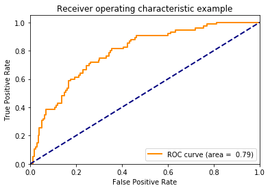

```python
plot_roc_curve(fpr, tpr, roc_auc)
```

### 3. Decision Tree

#### 3-1. `sklearn.tree.DecisionTreeClassifier`

```python
# import packages
from sklearn.tree import DecisionTreeClassifier
```

```python
# set parameters
class_weight = 'balanced'
max_depth = 5
```

```python
# knn_model
dt_model = DecisionTreeClassifier(class_weight=class_weight, max_depth=max_depth)
dt_model
```

```
DecisionTreeClassifier(class_weight='balanced', criterion='gini', max_depth=5,
            max_features=None, max_leaf_nodes=None,
            min_impurity_split=1e-07, min_samples_leaf=1,
            min_samples_split=2, min_weight_fraction_leaf=0.0,
            presort=False, random_state=None, splitter='best')
```

```python
# fit to model
dt_model.fit(X=X_train, y=y_train)
```

```
DecisionTreeClassifier(class_weight='balanced', criterion='gini', max_depth=5,
            max_features=None, max_leaf_nodes=None,
            min_impurity_split=1e-07, min_samples_leaf=1,
            min_samples_split=2, min_weight_fraction_leaf=0.0,
            presort=False, random_state=None, splitter='best')
```

```python
# get predictions
y_pred_dt = dt_model.predict(X=X_test)
y_pred_dt
```

```
array([0, 0, 0, 0, 1, 0, 1, 1, 0, 0, 0, 1, 0, 1, 1, 1, 0, 0, 1, 1, 0, 1, 0,
       1, 1, 0, 1, 1, 1, 1, 0, 1, 0, 0, 1, 1, 0, 1, 1, 1, 0, 1, 0, 0, 1, 0,
       1, 1, 1, 1, 0, 0, 0, 0, 1, 0, 0, 1, 1, 1, 1, 0, 1, 0, 0, 0, 1, 1, 0,
       1, 0, 0, 0, 0, 1, 1, 0, 1, 0, 1, 1, 1, 1, 1, 0, 0, 1, 0, 1, 1, 0, 1,
       0, 0, 1, 1, 0, 0, 0, 0, 1, 0, 0, 0, 1, 1, 0, 0, 0, 1, 0, 0, 1, 1, 0,
       0, 0, 0, 0, 0, 1, 1, 1, 0, 0, 1, 0, 1, 1, 1, 1, 1, 0, 0, 0, 1, 0, 1,
       0, 0, 0, 0, 0, 0, 0, 1, 1, 1, 1, 0, 0, 0, 0, 1, 1, 0, 0, 1, 0, 0, 1,
       0, 0, 0, 1, 1, 0, 1, 0, 1, 0, 0, 1, 1, 0, 1, 0, 1, 0, 1, 1, 0, 1, 0,
       1, 1, 0, 0, 1, 0, 1, 0, 0, 0, 1, 1, 0, 0, 1, 0, 1, 1, 1, 0, 1, 0, 0,
       0, 1, 0, 0, 1, 1, 0, 0, 1, 1, 1, 0, 0, 0, 1, 0, 1, 0, 1, 1, 0, 1, 1,
       1, 0, 1, 1, 1, 1, 0, 0, 1, 1, 0, 1, 0, 0, 1, 1, 0, 0, 1, 1])
```

```python
# get score
dt_model.score(X=X_test, y=y_test)
```

```
0.64400000000000002
```

```python
# result_y_test_df
result_y_test_df['dt'] = y_pred_dt
result_y_test_df
```

| OBS# | RESPONSE | lr | dt |
| --- | --- | --- | --- |
| 507 | 1 | 1 | 0 |
| 990 | 0 | 0 | 0 |
| 168 | 0 | 0 | 0 |
| 880 | 0 | 0 | 0 |
| 945 | 0 | 1 | 1 |
| 969 | 0 | 1 | 0 |
| 11 | 1 | 1 | 1 |
| 48 | 0 | 0 | 1 |
| 241 | 0 | 0 | 0 |
| 45 | 0 | 0 | 0 |
| 533 | 0 | 0 | 0 |
| 524 | 0 | 1 | 1 |
| 895 | 0 | 0 | 0 |
| 251 | 0 | 0 | 1 |
| 460 | 0 | 1 | 1 |
| 68 | 1 | 1 | 1 |
| 276 | 0 | 0 | 0 |
| 662 | 0 | 0 | 0 |
| 320 | 1 | 1 | 1 |
| 212 | 1 | 1 | 1 |
| 412 | 1 | 0 | 0 |
| 438 | 0 | 1 | 1 |
| 81 | 0 | 0 | 0 |
| 521 | 1 | 1 | 1 |
| 645 | 1 | 0 | 1 |
| 838 | 0 | 0 | 0 |
| 130 | 0 | 1 | 1 |
| 583 | 1 | 1 | 1 |
| 714 | 1 | 1 | 1 |
| 463 | 0 | 0 | 1 |
| ... | ... | ... | ... |
| 26 | 0 | 0 | 0 |
| 464 | 0 | 0 | 1 |
| 688 | 0 | 0 | 0 |
| 109 | 0 | 0 | 1 |
| 82 | 0 | 0 | 0 |
| 239 | 0 | 0 | 1 |
| 148 | 0 | 1 | 1 |
| 575 | 0 | 0 | 0 |
| 42 | 0 | 0 | 1 |
| 545 | 1 | 1 | 1 |
| 606 | 0 | 0 | 1 |
| 309 | 0 | 1 | 0 |
| 359 | 1 | 1 | 1 |
| 624 | 1 | 1 | 1 |
| 923 | 0 | 1 | 1 |
| 217 | 0 | 0 | 1 |
| 541 | 0 | 0 | 0 |
| 553 | 0 | 1 | 0 |
| 872 | 0 | 0 | 1 |
| 47 | 0 | 0 | 1 |
| 627 | 1 | 0 | 0 |
| 931 | 1 | 1 | 1 |
| 879 | 0 | 0 | 0 |
| 379 | 0 | 0 | 0 |
| 340 | 0 | 1 | 1 |
| 964 | 0 | 1 | 1 |
| 404 | 0 | 1 | 0 |
| 739 | 1 | 1 | 0 |
| 818 | 0 | 1 | 1 |
| 229 | 0 | 1 | 1 |

250 rows × 3 columns

```python
# confusion matrix
confusion_matrix(y_pred=y_pred_dt, y_true=y_test)
```

```
array([[107,  68],
       [ 21,  54]])
```

#### 3-2. How Does it Decide? - Visualization of Decision Tree via `graphviz`

```python
# import packages
from sklearn.tree import export_graphviz
```

```python
# export tree as .dot
with open('test_tree.dot', 'w') as f:
    export_graphviz(dt_model, f, feature_names=preprocessed_df.columns)
```

```python
# import packages for draw tree
import graphviz

# INSTALLATION :
# conda install pip
# pip install graphviz
```

```python
# open .dot & visualize
with open('test_tree.dot', 'r') as f:
    dot_graph = f.read()
graphviz.Source(dot_graph)
```

[figure not shown]

```python
# export to .png
# $ dot -Tpng tree.dot -o tree.png
```

#### 3-3. Interpret Clustering by Decision Tree

```python
# open bath_soap_clustering.df
import pickle
with open('bath_soap_clustering.df', 'rb') as f:
    clustering_df = pickle.load(f)
```

```python
# build DT - max_depth, min_samples_leaf, class_weight
ip_model = DecisionTreeClassifier(max_depth=3, class_weight='balanced', min_samples_leaf=150).fit(X=clustering_df.drop('predicted_labels', axis=1)
                                                                            , y=clustering_df.predicted_labels)

# visualize
dot_filename = 'clustering_tree.dot'
with open(dot_filename, 'w') as f:
    export_graphviz(ip_model, f, feature_names=label_df.columns)

with open(dot_filename, 'r') as f:
    dot_graph = f.read()

graphviz.Source(dot_graph)
```

[figure not shown]

### 4. Random Forest

#### 4-1. `sklearn.ensemble.RandomForestClassifier`

```python
# import packages
from sklearn.ensemble import RandomForestClassifier
```

```python
# set parameters
n_estimators = 100
class_weight = 'balanced'
max_depth = 4
```

```python
#svm_model
rf_model = RandomForestClassifier(n_estimators=n_estimators, class_weight=class_weight, max_depth=max_depth)
rf_model
```

```
RandomForestClassifier(bootstrap=True, class_weight='balanced',
            criterion='gini', max_depth=4, max_features='auto',
            max_leaf_nodes=None, min_impurity_split=1e-07,
            min_samples_leaf=1, min_samples_split=2,
            min_weight_fraction_leaf=0.0, n_estimators=100, n_jobs=1,
            oob_score=False, random_state=None, verbose=0,
            warm_start=False)
```

```python
# fit to model
rf_model.fit(X=X_train, y=y_train)
```

```
RandomForestClassifier(bootstrap=True, class_weight='balanced',
            criterion='gini', max_depth=4, max_features='auto',
            max_leaf_nodes=None, min_impurity_split=1e-07,
            min_samples_leaf=1, min_samples_split=2,
            min_weight_fraction_leaf=0.0, n_estimators=100, n_jobs=1,
            oob_score=False, random_state=None, verbose=0,
            warm_start=False)
```

```python
# get predictions
y_pred_rf = rf_model.predict(X=X_test)
```

```python
rf_model.score(X=X_test, y=y_test)
```

```
0.68799999999999994
```

```python
# result_y_test_df
result_y_test_df['rf'] = y_pred_rf
result_y_test_df
```

| OBS# | RESPONSE | lr | dt | rf |
| --- | --- | --- | --- | --- |
| 507 | 1 | 1 | 0 | 1 |
| 990 | 0 | 0 | 0 | 0 |
| 168 | 0 | 0 | 0 | 0 |
| 880 | 0 | 0 | 0 | 0 |
| 945 | 0 | 1 | 1 | 1 |
| 969 | 0 | 1 | 0 | 0 |
| 11 | 1 | 1 | 1 | 1 |
| 48 | 0 | 0 | 1 | 0 |
| 241 | 0 | 0 | 0 | 0 |
| 45 | 0 | 0 | 0 | 0 |
| 533 | 0 | 0 | 0 | 0 |
| 524 | 0 | 1 | 1 | 1 |
| 895 | 0 | 0 | 0 | 0 |
| 251 | 0 | 0 | 1 | 0 |
| 460 | 0 | 1 | 1 | 1 |
| 68 | 1 | 1 | 1 | 0 |
| 276 | 0 | 0 | 0 | 0 |
| 662 | 0 | 0 | 0 | 0 |
| 320 | 1 | 1 | 1 | 1 |
| 212 | 1 | 1 | 1 | 1 |
| 412 | 1 | 0 | 0 | 0 |
| 438 | 0 | 1 | 1 | 1 |
| 81 | 0 | 0 | 0 | 0 |
| 521 | 1 | 1 | 1 | 1 |
| 645 | 1 | 0 | 1 | 0 |
| 838 | 0 | 0 | 0 | 1 |
| 130 | 0 | 1 | 1 | 1 |
| 583 | 1 | 1 | 1 | 1 |
| 714 | 1 | 1 | 1 | 1 |
| 463 | 0 | 0 | 1 | 0 |
| ... | ... | ... | ... | ... |
| 26 | 0 | 0 | 0 | 0 |
| 464 | 0 | 0 | 1 | 0 |
| 688 | 0 | 0 | 0 | 0 |
| 109 | 0 | 0 | 1 | 0 |
| 82 | 0 | 0 | 0 | 0 |
| 239 | 0 | 0 | 1 | 1 |
| 148 | 0 | 1 | 1 | 1 |
| 575 | 0 | 0 | 0 | 0 |
| 42 | 0 | 0 | 1 | 1 |
| 545 | 1 | 1 | 1 | 1 |
| 606 | 0 | 0 | 1 | 0 |
| 309 | 0 | 1 | 0 | 1 |
| 359 | 1 | 1 | 1 | 1 |
| 624 | 1 | 1 | 1 | 1 |
| 923 | 0 | 1 | 1 | 1 |
| 217 | 0 | 0 | 1 | 1 |
| 541 | 0 | 0 | 0 | 0 |
| 553 | 0 | 1 | 0 | 0 |
| 872 | 0 | 0 | 1 | 1 |
| 47 | 0 | 0 | 1 | 0 |
| 627 | 1 | 0 | 0 | 0 |
| 931 | 1 | 1 | 1 | 1 |
| 879 | 0 | 0 | 0 | 0 |
| 379 | 0 | 0 | 0 | 0 |
| 340 | 0 | 1 | 1 | 1 |
| 964 | 0 | 1 | 1 | 1 |
| 404 | 0 | 1 | 0 | 0 |
| 739 | 1 | 1 | 0 | 1 |
| 818 | 0 | 1 | 1 | 1 |
| 229 | 0 | 1 | 1 | 1 |

250 rows × 4 columns

#### 4-2. Change Threshold to Decide

```python
# import numpy
import numpy as np
```

```python
# change Treshold

# .predict_prob
# acurracy
y_pred_prob = rf_model.predict_proba(X=X_test)
thresholds = np.arange(0, 1, 0.01)

from sklearn.metrics import accuracy_score
threshold_accuracies = list()
for t in thresholds:
    threshold_accuracies.append(accuracy_score(y_pred=y_pred_prob[:, 1] > t, y_true=y_test))
    confusion_matrix(y_pred=y_pred_prob[:, 1] > t, y_true=y_test)
```

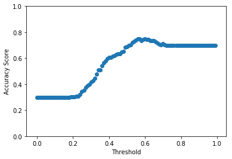

```python
# threshold vs. accuracy score
plt.figure()
plt.scatter(thresholds, threshold_accuracies)
plt.ylim([0, 1])
plt.xlabel('Threshold')
plt.ylabel('Accuracy Score')
plt.title('')
plt.show()
```

### 5. 실습 : 우량 등급 예측 모델

test set(random_state = 88)에 대한 accuracy가 가장 좋은 모델을 만들어라.

- Logistic Regression, Decision Tree, Random Forest 중 하나를 사용하라.
- 변수의 개수를 적절히 조절하거나,
- threshold를 변경하거나,
- 모델에 들어갈 parameter를 조절하여라.
- Cross Validation은 고려하지 않는다.

```python
from sklearn.ensemble import RandomForestClassifier
```

```python
# 모델 선택
model = RandomForestClassifier(n_estimators=100, max_depth=5)
```

```python
# 기본 성능 체크
model.fit(X=X_train, y=y_train)
model.score(X=X_test, y=y_test)
```

```
0.74399999999999999
```

```python
# 변수 선택
from sklearn.feature_selection import RFECV
selector = RFECV(estimator=model, cv=5)
selector.fit(X=X_train, y=y_train)
```

```python
rfe_model = selector.estimator_
X_test_rfe = selector.transform(X=X_test)
y_pred = rfe_model.predict(X=X_test_rfe)
```

- 위에서 구한 모델에 대한 이익을 계산하여라.
- 10개 이상의 경계값 후보를 살펴보고, 각 경계값별로 이익을 계산하고 최대 이익을 내는 경계값을 찾아라
- 최대 이익을 내는 경계값과 모델의 경계값이 동일한가? 그 이유는 무엇인가?

```python
# 이익 계산
from sklearn.metrics import confusion_matrix
sum(confusion_matrix(y_pred=y_pred, y_true=y_test).ravel() * [100, 0, -500, 0])
```

[output not shown]

```python
import numpy as np
from sklearn.metrics import accuracy_score

thresholds = np.arange(0, 1, 0.01) # 경계값 후보 찾기
y_pred_prob = selector.estimator_.predict_proba(X=X_test_rfe) # 예측 확률

result = pd.DataFrame(columns=['Accuracy', 'Confusion Matrix', 'Profit'])
for t in thresholds:
    y_pred =  y_pred_prob[:, 1] > t
    result.loc[t] = [accuracy_score(y_pred=y_pred, y_true=y_test) # Accuracy
                      , confusion_matrix(y_pred=y_pred, y_true=y_test).ravel() # Confusion Matrix
                      , sum(confusion_matrix(y_pred=y_pred, y_true=y_test).ravel() * [100, 0, -500, 0]) # Profit
                    ]
result
```

|  | Accuracy | Confusion Matrix | Profit |
| --- | --- | --- | --- |
| 0.00 | 0.300 | [0, 175, 0, 75] | 0 |
| 0.01 | 0.300 | [0, 175, 0, 75] | 0 |
| 0.02 | 0.300 | [0, 175, 0, 75] | 0 |
| 0.03 | 0.300 | [0, 175, 0, 75] | 0 |
| 0.04 | 0.300 | [0, 175, 0, 75] | 0 |
| 0.05 | 0.304 | [1, 174, 0, 75] | 100 |
| 0.06 | 0.312 | [3, 172, 0, 75] | 300 |
| 0.07 | 0.312 | [3, 172, 0, 75] | 300 |
| 0.08 | 0.336 | [9, 166, 0, 75] | 900 |
| 0.09 | 0.360 | [16, 159, 1, 74] | 1100 |
| 0.10 | 0.384 | [22, 153, 1, 74] | 1700 |
| 0.11 | 0.416 | [30, 145, 1, 74] | 2500 |
| 0.12 | 0.428 | [35, 140, 3, 72] | 2000 |
| 0.13 | 0.452 | [41, 134, 3, 72] | 2600 |
| 0.14 | 0.488 | [50, 125, 3, 72] | 3500 |
| 0.15 | 0.512 | [56, 119, 3, 72] | 4100 |
| 0.16 | 0.532 | [61, 114, 3, 72] | 4600 |
| 0.17 | 0.548 | [65, 110, 3, 72] | 5000 |
| 0.18 | 0.556 | [69, 106, 5, 70] | 4400 |
| 0.19 | 0.568 | [73, 102, 6, 69] | 4300 |
| 0.20 | 0.584 | [77, 98, 6, 69] | 4700 |
| 0.21 | 0.588 | [79, 96, 7, 68] | 4400 |
| 0.22 | 0.596 | [82, 93, 8, 67] | 4200 |
| 0.23 | 0.604 | [86, 89, 10, 65] | 3600 |
| 0.24 | 0.620 | [91, 84, 11, 64] | 3600 |
| 0.25 | 0.620 | [92, 83, 12, 63] | 3200 |
| 0.26 | 0.628 | [94, 81, 12, 63] | 3400 |
| 0.27 | 0.636 | [96, 79, 12, 63] | 3600 |
| 0.28 | 0.640 | [99, 76, 14, 61] | 2900 |
| 0.29 | 0.640 | [100, 75, 15, 60] | 2500 |
| ... | ... | ... | ... |
| 0.70 | 0.700 | [175, 0, 75, 0] | -20000 |
| 0.71 | 0.700 | [175, 0, 75, 0] | -20000 |
| 0.72 | 0.700 | [175, 0, 75, 0] | -20000 |
| 0.73 | 0.700 | [175, 0, 75, 0] | -20000 |
| 0.74 | 0.700 | [175, 0, 75, 0] | -20000 |
| 0.75 | 0.700 | [175, 0, 75, 0] | -20000 |
| 0.76 | 0.700 | [175, 0, 75, 0] | -20000 |
| 0.77 | 0.700 | [175, 0, 75, 0] | -20000 |
| 0.78 | 0.700 | [175, 0, 75, 0] | -20000 |
| 0.79 | 0.700 | [175, 0, 75, 0] | -20000 |
| 0.80 | 0.700 | [175, 0, 75, 0] | -20000 |
| 0.81 | 0.700 | [175, 0, 75, 0] | -20000 |
| 0.82 | 0.700 | [175, 0, 75, 0] | -20000 |
| 0.83 | 0.700 | [175, 0, 75, 0] | -20000 |
| 0.84 | 0.700 | [175, 0, 75, 0] | -20000 |
| 0.85 | 0.700 | [175, 0, 75, 0] | -20000 |
| 0.86 | 0.700 | [175, 0, 75, 0] | -20000 |
| 0.87 | 0.700 | [175, 0, 75, 0] | -20000 |
| 0.88 | 0.700 | [175, 0, 75, 0] | -20000 |
| 0.89 | 0.700 | [175, 0, 75, 0] | -20000 |
| 0.90 | 0.700 | [175, 0, 75, 0] | -20000 |
| 0.91 | 0.700 | [175, 0, 75, 0] | -20000 |
| 0.92 | 0.700 | [175, 0, 75, 0] | -20000 |
| 0.93 | 0.700 | [175, 0, 75, 0] | -20000 |
| 0.94 | 0.700 | [175, 0, 75, 0] | -20000 |
| 0.95 | 0.700 | [175, 0, 75, 0] | -20000 |
| 0.96 | 0.700 | [175, 0, 75, 0] | -20000 |
| 0.97 | 0.700 | [175, 0, 75, 0] | -20000 |
| 0.98 | 0.700 | [175, 0, 75, 0] | -20000 |
| 0.99 | 0.700 | [175, 0, 75, 0] | -20000 |

100 rows × 3 columns

Profit을 최대로 하는 Threshold와 Accuracy를 최대로 하는 Threshold는 같을까?

```python
print(result.loc[result.Profit.idxmax(), :])
print(result.loc[result.Accuracy.idxmax(), :])
```

```
Accuracy                       0.548
Confusion Matrix    [65, 110, 3, 72]
Profit                          5000
Name: 0.17, dtype: object
Accuracy                        0.76
Confusion Matrix    [173, 2, 58, 17]
Profit                        -11700
Name: 0.52, dtype: object
```